# Graph Neural Networks

Tao ZOU

2023-12-13

# Graph

## Plot a graph

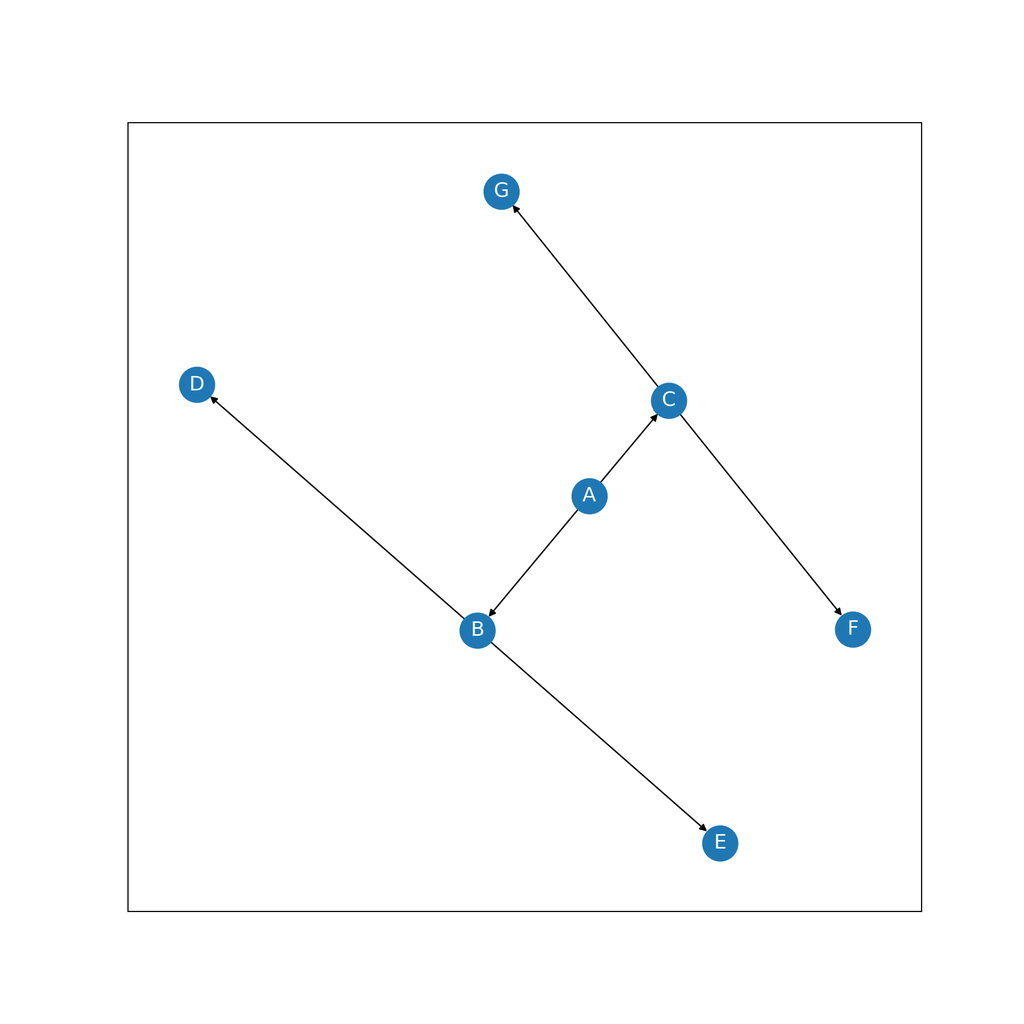

```python
import networkx as nx
import matplotlib.pyplot as plt

WG = nx.DiGraph()
WG.add_edges_from([('A', 'B', {"weight": 10}), ('A', 'C', {"weight": 20}), ('B', 'D', {"weight": 30}), ('B', 'E', {"weight": 40}), ('C', 'F', {"weight": 50}), ('C', 'G', {"weight": 60})])
labels = nx.get_edge_attributes(WG, "weight")

#plt.axis('off')
nx.draw_networkx(WG,
        pos=nx.spring_layout(WG, seed=0),
        node_size=600,
        cmap='coolwarm',
        font_size=14,
        font_color='white'
        )
plt.show()
# nx.draw_networkx_edge_labels(WG, pos=nx.spring_layout(WG, seed=0), edge_labels=labels)
```

## Graph measures

- **Degree centrality**: the dgree of the node
- **Closeness centrality**: the average length of the shortest path between the target node and all other nodes in a graph.
- **Betweenness centrality**: the number of times a node lies on the shortest path between pairs of other nodes in a graph.

```python
print(f'Degree centrality: {nx.degree_centrality(WG)}')
```

```
## Degree centrality: {'A': 0.3333333333333333, 'B': 0.5, 'C': 0.5, 'D': 0.16666666666666666, 'E': 0.16666666666666666, 'F': 0.16666666666666666, 'G': 0.16666666666666666}
```

```python
print(f'Closeness centrality: {nx.closeness_centrality(WG)}')
```

```
## Closeness centrality: {'A': 0.0, 'B': 0.16666666666666666, 'C': 0.16666666666666666, 'D': 0.2222222222222222, 'E': 0.2222222222222222, 'F': 0.2222222222222222, 'G': 0.2222222222222222}
```

```python
print(f'Betweenness centrality: {nx.betweenness_centrality(WG)}')
```

```
## Betweenness centrality: {'A': 0.0, 'B': 0.06666666666666667, 'C': 0.06666666666666667, 'D': 0.0, 'E': 0.0, 'F': 0.0, 'G': 0.0}
```

## Dataset

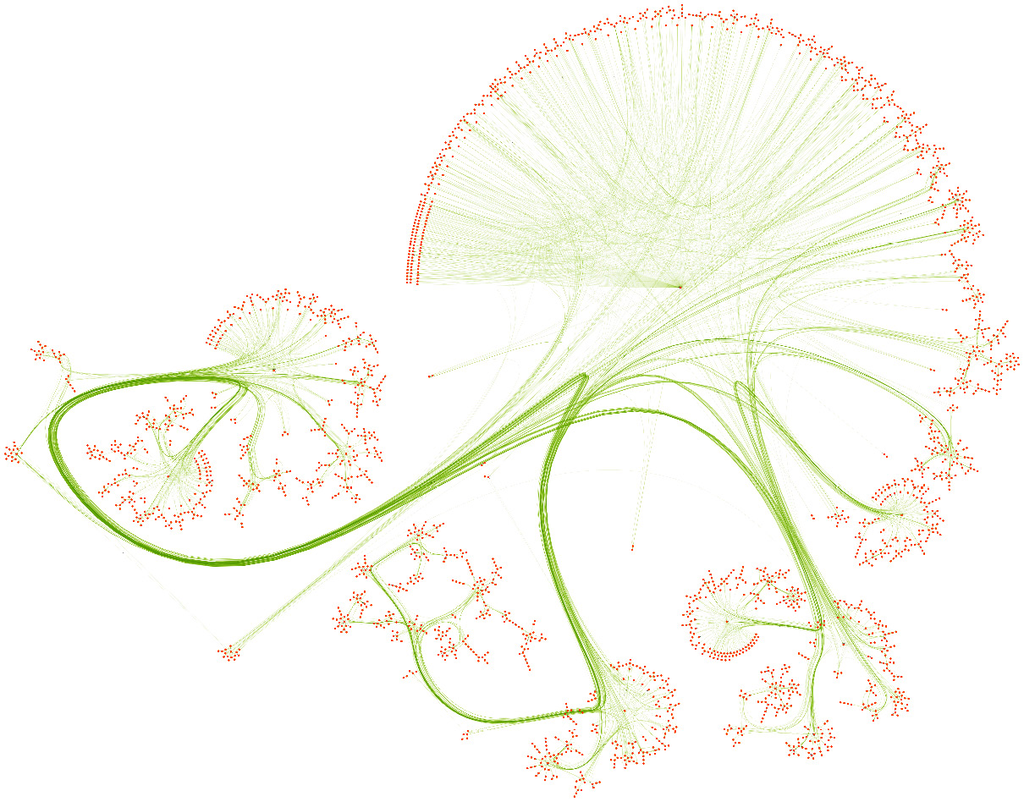

Dense Graph of Core (https://github.com/PacktPublishing/Hands-On-Graph-Neural-Networks-Using-Python)

```python
from torch_geometric.datasets import Planetoid
import pandas as pd

# Import dataset from PyTorch Geometric
dataset = Planetoid(root=".", name="Cora")
data = dataset[0]

# Print information about the dataset
print(f'Dataset: {dataset}')
print('---------------')
print(f'Number of graphs: {len(dataset)}')
print(f'Number of nodes: {data.x.shape[0]}')
print(f'Number of features: {dataset.num_features}')
print(f'Number of classes: {dataset.num_classes}')

# Print information about the graph
print(f'\nGraph:')
print('------')
print(f'Edges are directed: {data.is_directed()}')
print(f'Graph has isolated nodes: {data.has_isolated_nodes()}')
print(f'Graph has loops: {data.has_self_loops()}')

df_x = pd.DataFrame(data.x.numpy())
df_x['label'] = pd.DataFrame(data.y)
df_x  # Show the dataset
```

[output not shown]

# The basic GNNs: vanilla GNNs

Suppose $\begin{bmatrix}x_{11}&x_{12}&\cdots&x_{1d}\end{bmatrix}$ is features for node $A$. In neural network field, there is

$$\begin{bmatrix}x_{11}&x_{12}&\cdots&x_{1d}\end{bmatrix}\begin{bmatrix}w_{11}&w_{12}&\cdots&w_{1h}\\w_{21}&w_{22}&\cdots&w_{2h}\\\vdots&\vdots&\ddots&\vdots\\w_{d1}&w_{d2}&\cdots&w_{dh}\end{bmatrix}=\begin{bmatrix}h_{11}&h_{12}&\cdots&h_{1h}\end{bmatrix}$$
.

Suppose $A$ has two neighbors. In vanilla GNNs, there is

$$\begin{aligned}
Node\ A:\ \
\begin{bmatrix}x_{11}&x_{12}&\cdots&x_{1d}\end{bmatrix}\begin{bmatrix}w_{11}&w_{12}&\cdots&w_{1h}\\w_{21}&w_{22}&\cdots&w_{2h}\\\vdots&\vdots&\ddots&\vdots\\w_{d1}&w_{d2}&\cdots&w_{dh}\end{bmatrix}&=\begin{bmatrix}h_{11}^{(A)}&h_{12}^{(A)}&\cdots&h_{1h}^{(A)}\end{bmatrix}\\
Neighbor_i\ of\ A:\ \
\begin{bmatrix}x_{i1}&x_{i2}&\cdots&x_{id}\end{bmatrix}\begin{bmatrix}w_{11}&w_{12}&\cdots&w_{1h}\\w_{21}&w_{22}&\cdots&w_{2h}\\\vdots&\vdots&\ddots&\vdots\\w_{d1}&w_{d2}&\cdots&w_{dh}\end{bmatrix}&=\begin{bmatrix}h_{11}^{(i)}&h_{12}^{(i)}&\cdots&h_{1h}^{(i)}\end{bmatrix}\\
Neighbor_j\ of\ A:\ \
\begin{bmatrix}x_{j1}&x_{j2}&\cdots&x_{jd}\end{bmatrix}\begin{bmatrix}w_{11}&w_{12}&\cdots&w_{1h}\\w_{21}&w_{22}&\cdots&w_{2h}\\\vdots&\vdots&\ddots&\vdots\\w_{d1}&w_{d2}&\cdots&w_{dh}\end{bmatrix}&=\begin{bmatrix}h_{11}^{(j)}&h_{12}^{(j)}&\cdots&h_{1h}^{(j)}\end{bmatrix}\\
\end{aligned}$$

The hidden layer of node $A$ is calculated by the following formula:

$$\begin{matrix}
\begin{bmatrix}h_{11}^{(A)}&h_{12}^{(A)}&\cdots&h_{1h}^{(A)}\end{bmatrix}\\
+\\
\begin{bmatrix}h_{11}^{(i)}&h_{12}^{(i)}&\cdots&h_{1h}^{(i)}\end{bmatrix}&\mathop{\longrightarrow}^\limits{\color{red}{sum}}&\begin{bmatrix}h_{11}&h_{12}&\cdots&h_{1h}\end{bmatrix}\\
+\\
\begin{bmatrix}h_{11}^{(j)}&h_{12}^{(j)}&\cdots&h_{1h}^{(j)}\end{bmatrix}
\end{matrix}$$

Here is the matrix expression:
$$\boldsymbol{H}_{(n,h)}=\big{(}\boldsymbol{A}_{(n,n)}+\boldsymbol{I}_{(n,n)}\big{)}^T\boldsymbol{X}_{(n,d)}{\boldsymbol{W}^T}_{(d,h)}$$
, where $n$ is the number of nodes in a graph, $\boldsymbol{A}$ is the adjacency matrix of the graph.

Through the formula above, the neighbor information of a node is inputted into networks.

```python
import torch
torch.manual_seed(0)
import torch.nn.functional as F
from torch_geometric.utils import to_dense_adj

class VanillaGNNLayer(torch.nn.Module):
    def __init__(self, dim_in, dim_out):
        super().__init__()
        self.linear = torch.nn.Linear(dim_in, dim_out, bias=False)

    def forward(self, x, adjacency):
        x = self.linear(x)
        x = torch.sparse.mm(adjacency, x)
        return x

class VanillaGNN(torch.nn.Module):
    """Vanilla Graph Neural Network"""
    def __init__(self, dim_in, dim_h, dim_out):
        super().__init__()
        self.gnn1 = VanillaGNNLayer(dim_in, dim_h)
        self.gnn2 = VanillaGNNLayer(dim_h, dim_out)

    def forward(self, x, adjacency):
        h = self.gnn1(x, adjacency)
        h = torch.relu(h)
        h = self.gnn2(h, adjacency)
        return F.log_softmax(h, dim=1)

    def fit(self, data, epochs):
        criterion = torch.nn.CrossEntropyLoss()
        optimizer = torch.optim.Adam(self.parameters(),
                                      lr=0.01,
                                      weight_decay=5e-4)

        self.train()
        for epoch in range(epochs+1):
            optimizer.zero_grad()
            out = self(data.x, adjacency)
            loss = criterion(out[data.train_mask], data.y[data.train_mask])
            acc = accuracy(out[data.train_mask].argmax(dim=1),
                          data.y[data.train_mask])
            loss.backward()
            optimizer.step()

            if(epoch % 20 == 0):
                val_loss = criterion(out[data.val_mask], data.y[data.val_mask])
                val_acc = accuracy(out[data.val_mask].argmax(dim=1),
                                  data.y[data.val_mask])
                print(f'Epoch {epoch:>3} | Train Loss: {loss:.3f} | Train Acc:'
                      f' {acc*100:>5.2f}% | Val Loss: {val_loss:.2f} | '
                      f'Val Acc: {val_acc*100:.2f}%')

    @torch.no_grad()
    def test(self, data):
        self.eval()
        out = self(data.x, adjacency)
        acc = accuracy(out.argmax(dim=1)[data.test_mask], data.y[data.test_mask])
        return acc
```

```python
# Load Cora dataset
dataset = Planetoid(root=".", name="Cora")
data = dataset[0]

#
adjacency = to_dense_adj(data.edge_index)[0]
adjacency += torch.eye(len(adjacency))

# Create the Vanilla GNN model
gnn = VanillaGNN(dataset.num_features, 16, dataset.num_classes)
print(gnn)

# Train
gnn.fit(data, epochs=100)

# Test
acc = gnn.test(data)
print(f'\nGNN test accuracy: {acc*100:.2f}%')
```

[output not shown]

# Graph Convolutional Networks (GCNs)

The main problem of vanilla GNNs is that it doesn’t take into account the difference in the number of neighbors nor the number of neighbors’ neighbors.

$$h_A=\sum_{i\in
N_A}\vec{x}_i\boldsymbol{W}$$
can be modified as
$$h_A=\sum_{i\in
N_A}\frac{1}{\sqrt{degree(A)}\sqrt{degree(i)}}\vec{x}_i\boldsymbol{W}$$
, where $N_A$ represents the neighbors of node $A$.

Here is the matrix expression:

$$\boldsymbol{H}=\big{(}\boldsymbol{D}+\boldsymbol{I}\big{)}^{-\frac{1}{2}}\big{(}\boldsymbol{A}+\boldsymbol{I}\big{)}^T\big{(}\boldsymbol{D}+\boldsymbol{I}\big{)}^{-\frac{1}{2}}\boldsymbol{X}\boldsymbol{W}^T$$

```python
import torch
torch.manual_seed(1)
import torch.nn.functional as F
from torch_geometric.nn import GCNConv

def accuracy(y_pred, y_true):
    """Calculate accuracy."""
    return torch.sum(y_pred == y_true) / len(y_true)


class GCN(torch.nn.Module):
    """Graph Convolutional Network"""
    def __init__(self, dim_in, dim_h, dim_out):
        super().__init__()
        self.gcn1 = GCNConv(dim_in, dim_h)
        self.gcn2 = GCNConv(dim_h, dim_out)

    def forward(self, x, edge_index):
        h = self.gcn1(x, edge_index)
        h = torch.relu(h)
        h = self.gcn2(h, edge_index)
        return F.log_softmax(h, dim=1)

    def fit(self, data, epochs):
        criterion = torch.nn.CrossEntropyLoss()
        optimizer = torch.optim.Adam(self.parameters(),
                                      lr=0.01,
                                      weight_decay=5e-4)

        self.train()
        for epoch in range(epochs+1):
            optimizer.zero_grad()
            out = self(data.x, data.edge_index)
            loss = criterion(out[data.train_mask], data.y[data.train_mask])
            acc = accuracy(out[data.train_mask].argmax(dim=1),
                          data.y[data.train_mask])
            loss.backward()
            optimizer.step()

            if(epoch % 20 == 0):
                val_loss = criterion(out[data.val_mask], data.y[data.val_mask])
                val_acc = accuracy(out[data.val_mask].argmax(dim=1),
                                  data.y[data.val_mask])
                print(f'Epoch {epoch:>3} | Train Loss: {loss:.3f} | Train Acc:'
                      f' {acc*100:>5.2f}% | Val Loss: {val_loss:.2f} | '
                      f'Val Acc: {val_acc*100:.2f}%')

    @torch.no_grad()
    def test(self, data):
        self.eval()
        out = self(data.x, data.edge_index)
        acc = accuracy(out.argmax(dim=1)[data.test_mask], data.y[data.test_mask])
        return acc
```

```python
# Load Cora dataset
dataset = Planetoid(root=".", name="Cora")
data = dataset[0]

# Create the Vanilla GNN model
gcn = GCN(dataset.num_features, 16, dataset.num_classes)
print(gcn)

# Train
gcn.fit(data, epochs=100)

# Test
acc = gcn.test(data)
print(f'\nGCN test accuracy: {acc*100:.2f}%\n')
```

[output not shown]